# PFI — le gestionnaire de contacts

## Consignes

- Ce travail est à faire **individuellement**;
- Ce travail est composé de 3 phases. Chaque phase sera publiée sur cette page;
- Soyez consistant dans la langue (anglais ou français);
- Découpez votre code en fonctions (une tâche → une fonction);
- Nommez vos données et fonctions avec des noms significatifs;
- L’enseignant peut moins vous guider pour ce travail, comparé aux laboratoires.

## Préparation du projet

Suivez les étapes suivantes, afin de préparer les ressources pour le projet :

1. Créez un fichier `index.html`;
2. Créez un fichier `main.js`;
3. Créez un fichier `styles.css`;
4. Dans `index.html`, ajoutez une référence vers une version minimisée de jQuery hébergée sur un CDN;
5. Dans `index.html`, ajoutez une référence vers `main.js`;
6. Dans `index.html`, ajoutez la balise suivante :  
   `<link rel="stylesheet" href="https://maxcdn.bootstrapcdn.com/bootstrap/3.4.0/css/bootstrap.min.css">`. Ceci est un fichier CSS situé sur un CDN;
7. Dans `index.html`, ajoutez une référence vers `styles.css`.
8. Dans le `body` d’`index.html`, ajoutez un `div` avec le id *contenu* ou *content* (choisissez entre français et anglais).

## Phase 1 : Chercher des données d’un service web et génération d’éléments du DOM

Tous le travail pour cette phase se produit dans `main.js`. Le but est de chercher des informations de contact d’un service web avec une requête HTTP.

### La fonction `creerTableContacts`/`createContactTable`

Créez une fonction `creerTableContacts`/`createContactTable` qui prend deux paramètres. Le premier paramètre est un objet de sélection jQuery. Le deuxième paramètre est un tableau.

**N.B. :** Il n’est pas nécessaire de valider les paramètres.

Le tableau contiendra des objets qui représentent chacun un contact. Chaque contact a plusieurs propriétés, soit son *id*, son *nom*, son *email*, etc. Tenez pour acquis que chaque contact a *les mêmes propriétés dans le même ordre*.

Le but de cette fonction est de générer une `table` HTML en utilisant les contacts comme contexte de données.

La syntaxe pour une `table` HTML est :

```
<table>
  <thead>
    <tr>
      <th>...</th>
      <th>...</th>
      ...
    </tr>
  </thead>
  <tbody>
    <tr>
      <td>...</td>
      <td>...</td>
      ...
    </tr>
    <tr>
      <td>...</td>
      <td>...</td>
      ...
    </tr>
    ...
  </tbody>
</table>
```

En utilisant `document.createElement(...)`, `.appendChild(...)` et des boucles, vous pouvez créer une `table` de façon dynamique.

**N.B. :** N’oubliez pas la différence entre un `for of` et un `for in` ! Un `for of` est pratique pour itérer entre chaque élément d’un tableau. Un `for in` est pratique pour itérer entre chaque propriété d’un objet (chaque clé d’un tableau associatif).

Ajoutez les classes CSS *table* et *table-striped* à la `table`. Ces classes viennent du fichier *bootstrap.min.css* référé.

Votre fonction doit, finalement, insérer la `table` créée dans la balise sélectionnée de l’objet jQuery (le premier paramètre).

#### Tester la fonction

```javascript
window.onload = function() {
  let contactData = [{"Id" : 0, "Name" : "Bob Bobo"},{"Id" : 1, "Name" : "Caro Carcaro"}];
  createContactTable($("#content"), contactData);
}
```

[figure not shown]

```javascript
window.onload = function() {
  let contactData = [{"Age" : 34, "Name" : "Bob Bobo", "Email" : "bongo12@gmail.com"},{"Age" : 29, "Name" : "Caro Carcaro", "Email" : "busmagique90@gmail.com"}];
  createContactTable($("#content"), contactData);
}
```

[figure not shown]

### La requête HTTP

En utilisant `$.get(...)` avec l’URL http://www.informatique.clg.qc.ca/KB5_Contacts/api/Contacts (aucun paramètre dans l’URL), cherchez de l’information de contacts. L’URL pointe vers un service web qui retourne la réponse JSON suivante :

```
[
  {
    "Id":1,
    "Name":"Thérèse Cripies",
    "Phone":"(514) 806-8030",
    "Email":"therescrispie@gmail.com",
    "Sexe":1,
    "Birthdate":"1950-05-19T00:00:00",
    "Single":true
  },
  {
    "Id":2,
    "Name":"Armande Zampu",
    "Phone":"(450) 430-3120",
    "Email":"Armande.Zampue@gmail.com",
    "Sexe":1,
    "Birthdate":"1970-02-01T00:00:00",
    "Single":false},
  {
    "Id":3,
    "Name":"Alain Proviste",
    "Phone":"(450) 430-3120",
    "Email":"ALainProviste@hotmail.com",
    "Sexe":0,
    "Birthdate":"1965-01-01T00:00:00",
    "Single":true
  }
]
```

Votre page doit, dans un premier temps, faire la requête. En deuxième lieu, elle doit créer une `table` dans le `div` *content* avec `createContactTable` où les contacts sont ceux retournés par la requête.

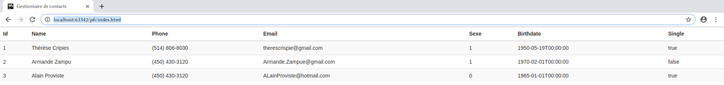

## Phase 2 : Le formulaire d’ajout de contacts

En bas de la `table`, créer un formulaire de saisie de contact. Le formulaire doit avoir les champs suivants :

- Prénom et Nom : type text;
- Téléphone : type tel;
- Courriel : type email;
- Date de naissance : type date;
- Sexe : groupe de 3 type radio;
  - la `value` 0 → M;
  - 1 → F;
  - 2 → Autre.
- Célibataire : type checkbox.

Tous les champs doivent avoir une valeur (`required`) avant la soumission du formulaire. Un checkbox a toujours une valeur (`false` lorsque non coché et `true` lorsque coché).

Styliser le formulaire avec du CSS. Assurez-vous que le tout est propre, lisible et bien aligné. Aussi, les radios et le checkbox doivent être étiquettés. Mettez également des `placeholder` appropriés aux champs.

Finalement, ajoutez un bouton de soumission au formulaire. Lorsque le formulaire est soumis, vous devez créer un nouvel objet représentant un contact avec les données saisies dans le formulaire. Utilisez `jQuery` pour chercher les valeurs des champs. Pour chercher la valeur `boolean` d’un checkbox, utilisez `$([insérez sélecteur]).is(":checked")`.

Le nouveau contact doit avoir les mêmes noms de propriétés que tous les autres contacts (`Name`, `Phone`, `Email`, etc.), **sauf** une propriété pour `ID`. Affichez cet objet dans la console et observez-le afin de vérifier si tout est en ordre.

Le `Name` devrait être une `string`; Le `Phone` devrait être une `string`; L’`Email` devrait être une `string`; Le `Sexe` devrait être un `number`; Le `Birthdate` devrait être une `string`; `Single` devrait êtrue un `boolean`;

## Phase 3 : Soumission du nouveau contact au service web

Au lieu d’utiliser `$.get(...)` avec des paramètres dans l’URL pour envoyer des données à un serveur, vous devez utiliser une autre méthode.

En utilisant la méthode `$.post(...)`, vous devez envoyer l’objet qui représente le nouveau contact au service web, afin qu’il l’ajoute dans la liste de contact. La prochaine fois que quelqu’un fera une requête au service pour chercher tous les contacts, le nouveau contact devrait être présent.

La fonction `post` de jQuery est une façon rapide de faire une requête AJAX pour soumettre un objet JS à un serveur. Vous pouvez utiliser la surcharge de la fonction à 3 paramètres :

1. URL du service web (le même que plus tôt);
2. la donnée à envoyer au serveur (ici, un objet);
3. une fonction de rappel (*callback*) qui est appelée une fois que la donnée a été acceptée par le serveur, suite à la soumission du client.

Si la soumission est réalisée avec succès, vous devez mettre à jour la page web, sans faire de rafraîchissement complet (*refresh*). Supprimez la `table` du DOM (chercher comment faire) et ajouter une nouvelle `table` avec tous les nouveaux contacts, au même endroit.

## Remise

Vous devez soumettre votre projet complet dans la boite de remise dédiée sur ColNet **avant minuit le 26 mai**. Assurez-vous que le tout fonctionne, car **AUCUN RETARD NE SERA ACCEPTÉ**.